# Homework #5

Andrew Sundberg

3/22/2019

## Liquor Sales in Iowa

This dataset https://data.iowa.gov/Economy/Iowa-Liquor-Sales/m3tr-qhgy contains the spirits purchase information of Iowa Class âEâ liquor licensees by product and date of purchase from January 1, 2012 to current. The dataset can be used to analyze total spirits sales in Iowa of individual products at the store level.

**Submission instructions**: Create a folder named `ds202_hw5`, and name the RMarkDown file including your solutions `hw5.Rmd` under this folder. For the submission, create a GitHub repository named `ds202_hw5` under your GitHub account, and push both `hw5.Rmd` and the knitted `hw5.html` before the deadline. I will assume you use the same GitHub username as for your HW4 submission. The latest version of your homework appearing on GitHub before the deadline is graded. *It is crucial to follow the exact folder structure and file names*, so that your homework can be reproduced and graded by an automated script. This homework is **due on April 11** before class.

## 1. The code below downloads the data for Ames only and saves a local copy to your machine. The first time you run this code, make sure you have a good internet connection and enough space on your machine (~50 MB). If the local copy exists, re-knitting the file will load the (binary) file from disk and be much faster.

```r
if (file.exists("alcohol.rds")) {
  data <- readRDS("alcohol.rds")
} else {
  url <- "https://xdaiisu.github.io/ds202materials/data/ames.csv"
  data <- readr::read_csv(url)
  saveRDS(data, file="alcohol.rds")
}
```

## 2. Data cleaning:

```r
library(tidyverse)
library(lubridate)
```

```r
library(ggplot2)

data1 = data %>% separate(`Store Location`, into = c('address1','address2', 'coordinates'), sep = '\n') %>%
  mutate(coordinates = gsub("[()]", "", coordinates)) %>%
  separate(coordinates, into = c('Latitude','Longitude'), sep = ',')
data1$Latitude = as.numeric(data1$Latitude)
data1$Longitude = as.numeric(data1$Longitude)
data1$`Store Name` = factor(data1$`Store Name`)
data1$Date = mdy(data1$Date)
data1$County = factor(data1$County)

data2 = data1 %>% separate(Date, into = c('Year', 'Month', 'Day'), sep = '-')
```

## 3. First overview:

- Plot a scatterplot of lat and long of store locations.

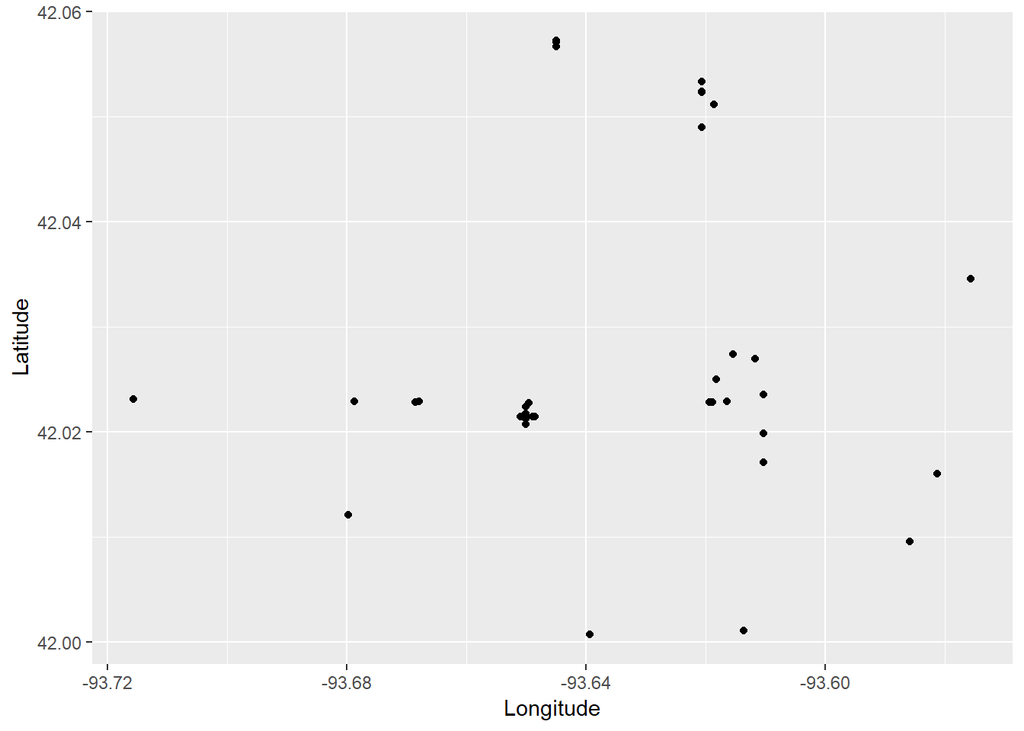

```r
ggplot(data2, aes(x = Longitude, y = Latitude)) + geom_point()
```

- Provide a visual breakdown of the liquor category (by `Category Name`). Include volume sold in the breakdown.

[figure not shown]

```r
ggplot(data2, aes(x = `Category Name`, y = `Volume Sold (Liters)`)) + geom_boxplot() + facet_wrap(~`Store Name`)
```

Find the dates for ISU football home games in Fall 2018. Can you see a pattern?

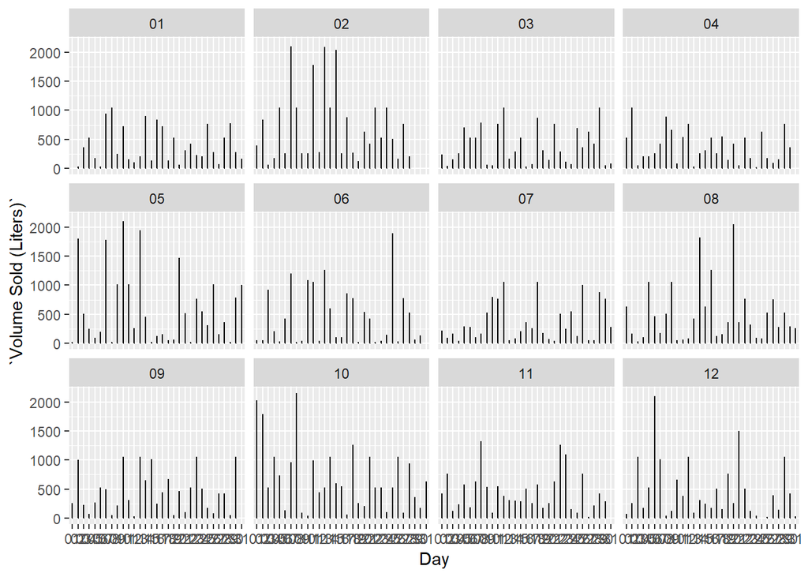

```r
ggplot(data2, aes(x = Day, y = `Volume Sold (Liters)`)) + geom_line() + facet_wrap(~Month)
```

At the beginning of May and the middle of August it looks like there are good selling times, because of students reuniting with their friends or they are saying goodbye to their friends for the summer. Also, it looks like there is a large amount sold in early December, probably marking the last party weekend before everyone goes home for the holidays. It looks like some days in early October sold a lot of alcohol but that might be because of midterms being over, same with the middle of February. It doesn’t seem that football games result in more alcohol sales.